# 3_Analysis

# Characteristics of included studies

Study characteristics

| name | nonmissing | count | min | max | mean | median | sd |
| --- | --- | --- | --- | --- | --- | --- | --- |
| blindAssign_Blind assignment | 13 | 1 | 0.00 | 1.00 | 0.08 | 0.00 | 0.28 |
| blindAssign_No blind assignment | 13 | 12 | 0.00 | 1.00 | 0.92 | 1.00 | 0.28 |
| compensation_Participants compensated | 13 | 5 | 0.00 | 1.00 | 0.38 | 0.00 | 0.51 |
| compensation_Participants not compensated | 13 | 8 | 0.00 | 1.00 | 0.62 | 1.00 | 0.51 |
| country_Other (Non-North America) | 13 | 8 | 0.00 | 1.00 | 0.62 | 1.00 | 0.51 |
| country_USA | 13 | 5 | 0.00 | 1.00 | 0.38 | 0.00 | 0.51 |
| interventionType_Indicated prevention | 13 | 7 | 0.00 | 1.00 | 0.54 | 1.00 | 0.52 |
| interventionType_Selective prevention | 13 | 1 | 0.00 | 1.00 | 0.08 | 0.00 | 0.28 |
| interventionType_Universal prevention | 13 | 5 | 0.00 | 1.00 | 0.38 | 0.00 | 0.51 |
| meanAge | 12 | 173 | 12.17 | 17.00 | 14.41 | 14.50 | 1.56 |
| optIn_Expectated to participate | 13 | 5 | 0.00 | 1.00 | 0.38 | 0.00 | 0.51 |
| optIn_Opt-in | 13 | 8 | 0.00 | 1.00 | 0.62 | 1.00 | 0.51 |
| pctFemale | 13 | 1106 | 50.38 | 100.00 | 85.12 | 100.00 | 21.40 |
| pctNonwhite | 11 | 198 | 4.82 | 42.00 | 17.99 | 16.50 | 10.31 |
| pctSexualMinority | 0 | 0 | Inf | -Inf | NaN | NA | NA |
| pubStatus_Not peer-reviewed | 13 | 1 | 0.00 | 1.00 | 0.08 | 0.00 | 0.28 |
| pubStatus_Peer-reviewed | 13 | 12 | 0.00 | 1.00 | 0.92 | 1.00 | 0.28 |
| riskScreen_Multiple/other | 13 | 1 | 0.00 | 1.00 | 0.08 | 0.00 | 0.28 |
| riskScreen_No risk screening | 13 | 6 | 0.00 | 1.00 | 0.46 | 0.00 | 0.52 |
| riskScreen_Screen on BD | 13 | 6 | 0.00 | 1.00 | 0.46 | 0.00 | 0.52 |
| sampleSource_Community sample | 13 | 12 | 0.00 | 1.00 | 0.92 | 1.00 | 0.28 |
| sampleSource_Other | 13 | 1 | 0.00 | 1.00 | 0.08 | 0.00 | 0.28 |
| studyCompletion.fu | 16 | 1376 | 59.62 | 100.35 | 86.03 | 91.66 | 12.45 |
| studyCompletion.post | 13 | 1132 | 43.97 | 100.00 | 87.08 | 89.72 | 14.82 |
| year | 13 | 26167 | 2006.00 | 2019.00 | 2012.85 | 2015.00 | 4.72 |

Measure characteristics

| name | nonmissing | count | min | max | mean | median | sd |
| --- | --- | --- | --- | --- | --- | --- | --- |
| measure_BDI-SF | 14 | 1 | 0 | 1 | 0.07 | 0 | 0.27 |
| measure_CDI | 14 | 1 | 0 | 1 | 0.07 | 0 | 0.27 |
| measure_CDI-SF | 14 | 2 | 0 | 1 | 0.14 | 0 | 0.36 |
| measure_CESD | 14 | 1 | 0 | 1 | 0.07 | 0 | 0.27 |
| measure_PANAS | 14 | 2 | 0 | 1 | 0.14 | 0 | 0.36 |
| measure_PANAS-10 | 14 | 1 | 0 | 1 | 0.07 | 0 | 0.27 |
| measure_PANAS-Child | 14 | 1 | 0 | 1 | 0.07 | 0 | 0.27 |
| measure_PANAS-X | 14 | 4 | 0 | 1 | 0.29 | 0 | 0.47 |
| measure_PHQ-9 | 14 | 1 | 0 | 1 | 0.07 | 0 | 0.27 |
| outcome_Depression Symptomatology | 14 | 6 | 0 | 1 | 0.43 | 0 | 0.51 |
| outcome_Trait Negative Affect | 14 | 8 | 0 | 1 | 0.57 | 1 | 0.51 |
| respondent_Youth-reported | 14 | 14 | 1 | 1 | 1.00 | 1 | 0.00 |

Common group characteristics

| name | nonmissing | count | min | max | mean | median | sd |
| --- | --- | --- | --- | --- | --- | --- | --- |
| fu1.n | 26 | 5548 | 17 | 728 | 213.39 | 122.5 | 208.88 |
| fu2.n | 17 | 2281 | 48 | 420 | 134.18 | 120.0 | 86.96 |
| post.n | 32 | 6021 | 15 | 842 | 188.15 | 116.0 | 225.38 |
| pre.n | 32 | 6821 | 23 | 1020 | 213.16 | 116.0 | 262.06 |
| randUnits.group | 30 | 1242 | 1 | 167 | 41.40 | 15.0 | 50.15 |

Treatment group characteristics

| name | nonmissing | count | min | max | mean | median | sd |
| --- | --- | --- | --- | --- | --- | --- | --- |
| deliveryFormat_Group | 18 | 16 | 0.00 | 1 | 0.89 | 1.00 | 0.32 |
| deliveryFormat_Self-administered | 18 | 2 | 0.00 | 1 | 0.11 | 0.00 | 0.32 |
| interventionParticipant_Parent | 18 | 3 | 0.00 | 1 | 0.17 | 0.00 | 0.38 |
| interventionParticipant_Youth | 18 | 15 | 0.00 | 1 | 0.83 | 1.00 | 0.38 |
| length.days | 18 | 571 | 1.00 | 238 | 31.72 | 21.00 | 52.81 |
| length.minutes | 16 | 5130 | 30.00 | 1530 | 320.62 | 240.00 | 353.00 |
| length.sessions | 18 | 98 | 1.00 | 34 | 5.44 | 3.00 | 7.50 |
| manual_NA | 18 | 2 | 0.00 | 1 | 0.11 | 0.00 | 0.32 |
| manual_Treatment manual used | 16 | 16 | 1.00 | 1 | 1.00 | 1.00 | 0.00 |
| manualAvail_Manual not publicly available | 16 | 6 | 0.00 | 1 | 0.38 | 0.00 | 0.50 |
| manualAvail_Manual publicly available | 16 | 10 | 0.00 | 1 | 0.62 | 1.00 | 0.50 |
| manualAvail_NA | 18 | 2 | 0.00 | 1 | 0.11 | 0.00 | 0.32 |
| preTraining_NA | 18 | 2 | 0.00 | 1 | 0.11 | 0.00 | 0.32 |
| preTraining_Training | 16 | 16 | 1.00 | 1 | 1.00 | 1.00 | 0.00 |
| provider_Clinician-administered | 18 | 14 | 0.00 | 1 | 0.78 | 1.00 | 0.43 |
| provider_Lay-administered | 18 | 1 | 0.00 | 1 | 0.06 | 0.00 | 0.24 |
| provider_Other | 18 | 1 | 0.00 | 1 | 0.06 | 0.00 | 0.24 |
| provider_Self-administered | 18 | 2 | 0.00 | 1 | 0.11 | 0.00 | 0.32 |
| supervision_NA | 18 | 2 | 0.00 | 1 | 0.11 | 0.00 | 0.32 |
| supervision_No supervision | 16 | 8 | 0.00 | 1 | 0.50 | 0.50 | 0.52 |
| supervision_Supervision | 16 | 8 | 0.00 | 1 | 0.50 | 0.50 | 0.52 |
| target_Body dissatisfaction | 18 | 5 | 0.00 | 1 | 0.28 | 0.00 | 0.46 |
| target_Other | 18 | 13 | 0.00 | 1 | 0.72 | 1.00 | 0.46 |
| trtCompletion | 11 | 906 | 50.63 | 100 | 82.39 | 81.41 | 15.06 |

Control group characteristics

| name | nonmissing | count | min | max | mean | median | sd |
| --- | --- | --- | --- | --- | --- | --- | --- |
| controlCond_Other | 14 | 1 | 0 | 1 | 0.07 | 0 | 0.27 |
| controlCond_Psychoeducation | 14 | 2 | 0 | 1 | 0.14 | 0 | 0.36 |
| controlCond_Waitlist/no treatment | 14 | 11 | 0 | 1 | 0.79 | 1 | 0.43 |

# Meta-analysis

Correlated-effects model with Robust Variance Estimation using `robumeta`

## Post-test effects

### Intercept-only model

#### Using post-test data only

```
## RVE: Correlated Effects Model with Small-Sample Corrections
##
## Model: g.post_t2 ~ 1
##
## Number of studies = 13
## Number of outcomes = 21 (min = 1 , mean = 1.62 , median = 1 , max = 4 )
## Rho = 0.8
## I.sq = 58.25911
## Tau.sq = 0.01798575
##
##                Estimate StdErr t-value  dfs P(|t|>) 95% CI.L 95% CI.U Sig
## 1 X.Intercept.   -0.192 0.0525   -3.65 9.32 0.00501    -0.31  -0.0736 ***
## ---
## Signif. codes: < .01 *** < .05 ** < .10 *
## ---
## Note: If df < 4, do not trust the results
```

```
## RVE: Correlated Effects Model with Small-Sample Corrections
## Model: g.post_t2 ~ 1
##
## Sensitivity Analysis
##
##                           Rho = 0 Rho = 0.2 Rho = 0.4 Rho = 0.6 Rho = 0.8
##  X.Intercept. Coefficient -0.1915 -0.1915   -0.1916   -0.1917   -0.1918
##               Std. Error   0.0525  0.0525    0.0525    0.0525    0.0525
##  Tau.sq       Estimate     0.0178  0.0178    0.0179    0.0179    0.0180
##  Rho = 1
##  -0.1919
##   0.0525
##   0.0180
```

Depression only

```
## RVE: Correlated Effects Model with Small-Sample Corrections
##
## Model: g.post_t2 ~ 1
##
## Number of studies = 6
## Number of outcomes = 7 (min = 1 , mean = 1.17 , median = 1 , max = 2 )
## Rho = 0.8
## I.sq = 61.08068
## Tau.sq = 0.01629322
##
##                Estimate StdErr t-value  dfs P(|t|>) 95% CI.L 95% CI.U Sig
## 1 X.Intercept.   -0.166 0.0692    -2.4 3.94  0.0754   -0.359   0.0273   *
## ---
## Signif. codes: < .01 *** < .05 ** < .10 *
## ---
## Note: If df < 4, do not trust the results
```

NA only

```
## RVE: Correlated Effects Model with Small-Sample Corrections
##
## Model: g.post_t2 ~ 1
##
## Number of studies = 8
## Number of outcomes = 14 (min = 1 , mean = 1.75 , median = 1.5 , max = 4 )
## Rho = 0.8
## I.sq = 56.69401
## Tau.sq = 0.03251229
##
##                Estimate StdErr t-value  dfs P(|t|>) 95% CI.L 95% CI.U Sig
## 1 X.Intercept.   -0.261 0.0915   -2.85 5.84  0.0301   -0.486  -0.0354  **
## ---
## Signif. codes: < .01 *** < .05 ** < .10 *
## ---
## Note: If df < 4, do not trust the results
```

Test of heterogeneity is the I^2 above

#### Using pre- and post-test data

```
## RVE: Correlated Effects Model with Small-Sample Corrections
##
## Model: g.post_t1t2 ~ 1
##
## Number of studies = 13
## Number of outcomes = 21 (min = 1 , mean = 1.62 , median = 1 , max = 4 )
## Rho = 0.8
## I.sq = 38.47034
## Tau.sq = 0.00804832
##
##                Estimate StdErr t-value  dfs P(|t|>) 95% CI.L 95% CI.U Sig
## 1 X.Intercept.   -0.176 0.0418   -4.21 7.94 0.00302   -0.272  -0.0792 ***
## ---
## Signif. codes: < .01 *** < .05 ** < .10 *
## ---
## Note: If df < 4, do not trust the results
```

### Forest plot:

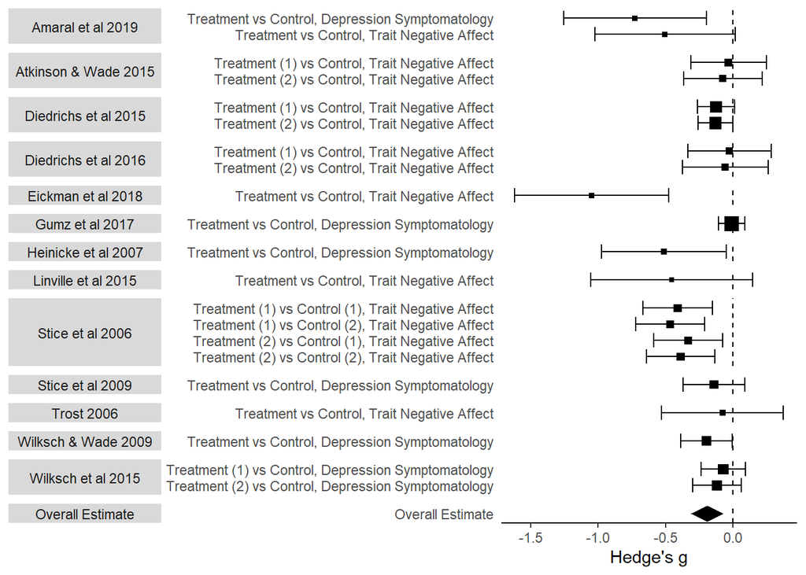

### Risk of bias assessment

We will assess publication bias with a funnel plot and Egger’s test. We do this by regressing each effect’s normalized effect estimate (estimate divided by its standard error) against precision (reciprocal of the standard error of the estimate) and testing the significance of the intercept.

```
## RVE: Correlated Effects Model with Small-Sample Corrections
##
## Model: gStd.post_t2 ~ 1 + precision.post_t2
##
## Number of studies = 13
## Number of outcomes = 21 (min = 1 , mean = 1.62 , median = 1 , max = 4 )
## Rho = 0.8
## I.sq = 98.28071
## Tau.sq = 0.8932174
##
##                     Estimate StdErr t-value  dfs P(|t|>) 95% CI.L 95% CI.U Sig
## 1      X.Intercept.  -2.1102  0.584   -3.61 6.77  0.0091  -3.5010   -0.720 ***
## 2 precision.post_t2   0.0719  0.050    1.44 2.88  0.2493  -0.0909    0.235
## ---
## Signif. codes: < .01 *** < .05 ** < .10 *
## ---
## Note: If df < 4, do not trust the results
```

In addition, we tested the following moderators, included in table below: `blindAssign`, `manual`, `preTraining`, `supervision`, `studyCompletion.post`

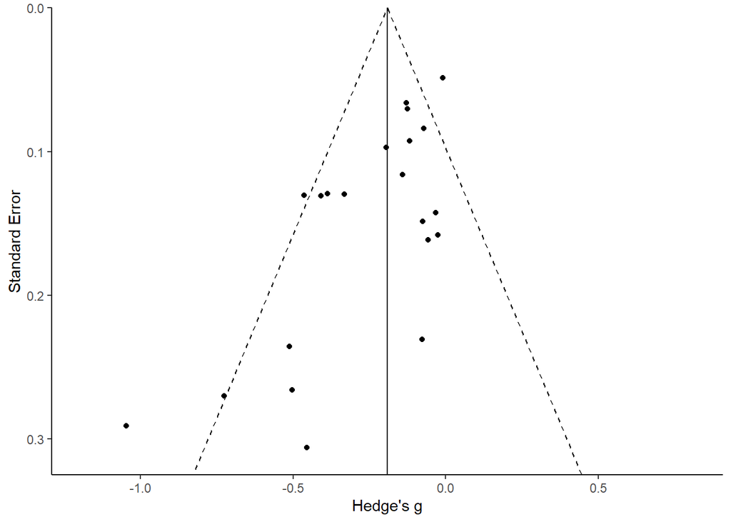

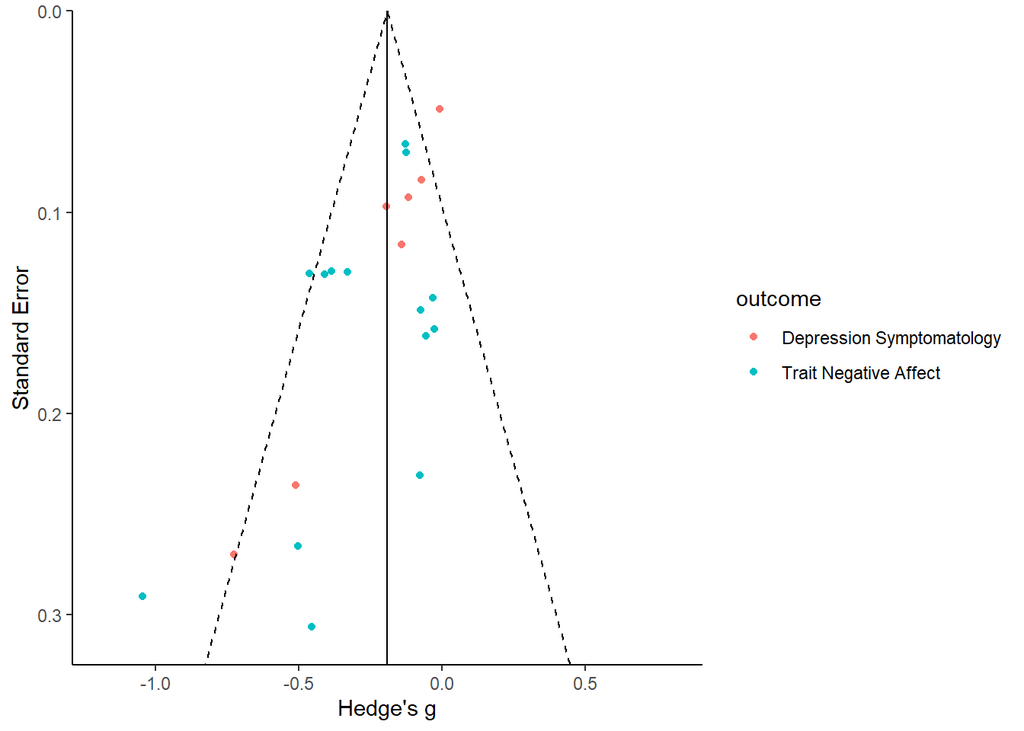

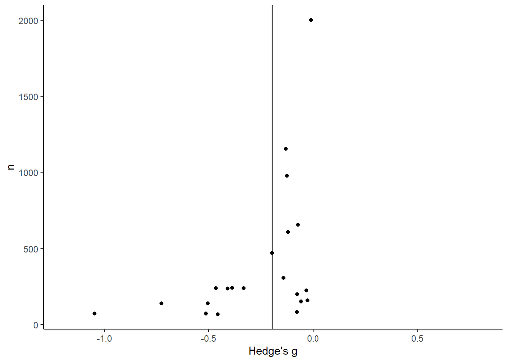

### Moderation tests

Moderation tests for each of the following variables (pre-registered), including subgroups with n >= 3 studies (not effect sizes).

See for minimum n/group in moderator test (they suggest 4, we use 3): Fu, R., Gartlehner, G., Grant, M., Shamliyan, T., Sedrakyan, A., Wilt, T. J., … & Trikalinos, T. A. (2011). Conducting quantitative synthesis when comparing medical interventions: AHRQ and the Effective Health Care Program. Journal of clinical epidemiology, 64(11), 1187-1197. https://www.researchgate.net/post/Does-anyone-have-any-citations-supporting-a-specific-number-of-studies-eg-3-or-more-per-subgroup-in-a-categorical-moderator-analysis

Pre-registered moderators: `year`, `pubStatus`, `country`, `sampleSource`, `meanAge`, `pctFemale`, `pctNonwhite`, `interventionType`, `riskScreen`, `outcome`, `controlCond`, `deliveryFormat`, `target`, `provider`, `supervision`, `length.minutes`, `length.sessions`, `length.days`, `trtCompletion`, `studyCompletion.post`

Added after pre-registration: `interventionParticipant`, `randUnits`

Moderators tested for quality assessment: `blindAssign`, `manual`, `preTraining`, `supervision`, `studyCompletion.post`

Dropped due to zero variation:

- `pctSexualMinority`: All `NA`
- `respondent`: All “Youth-reported”
- `manual`: All “Treatment manual used” or `NA`
- `preTraining`: All “Present” or `NA`

Dropped because only one category had >= 3 studies:

- `pubStatus`: Only 1 not “Peer-reviewed”
- `sampleSource`: Only 1 not “Community sample”
- `controlCond`: Only 2 “Psychoeducation,” 1 “Other”
- `delieryFormat`: Only 1 not “Group”
- `provider`: Only 1 “Self-administered,” 1 “Other”
- `interventionParticipant`: Only 2 not “Youth”
- `blindAssign`: Only 1 not “No blind assignment”

Dropped because couldn’t establish IRR:

- `target`

| moderator | level | nStudies | nES | Subgroup Analysis subgroupEst | Subgroup Analysis subgroupP | Subgroup Analysis coef | Moderator Test overallStat | Moderator Test overallP |
| --- | --- | --- | --- | --- | --- | --- | --- | --- |
| Year |  | 13 | 21 |  |  | 0.008 | t(6.588) = 0.573 | 0.586 |
| Country |  |  |  |  |  |  | t(4.896) = -1.545 | 0.184 |
|  | Other (Non-North America) | 8 | 13 | -0.117 | 0.041 |  |  |  |
|  | USA | 5 | 8 | -0.364 | 0.067 |  |  |  |
| Intervention Type |  |  |  |  |  |  | t(8.183) = 1.149 | 0.283 |
|  | Indicated prevention | 7 | 12 | -0.269 | 0.023 |  |  |  |
|  | Universal prevention | 5 | 7 | -0.153 | 0.112 |  |  |  |
| Risk Screening |  |  |  |  |  |  | t(7.331) = -1.085 | 0.312 |
|  | No risk screening | 6 | 9 | -0.135 | 0.076 |  |  |  |
|  | Screen on BD | 6 | 11 | -0.242 | 0.046 |  |  |  |
| Mean Age |  | 12 | 20 |  |  | -0.042 | t(4.094) = -1.625 | 0.178 |
| Percent Female |  | 13 | 21 |  |  | -0.003 | t(7.157) = -1.648 | 0.142 |
| Percent Non-white |  | 11 | 18 |  |  | -0.005 | t(2.173) = -1.251 | 0.329 |
| Length (Minutes) |  | 12 | 19 |  |  | -0.001 | t(1.692) = -3.008 | 0.116 |
| Length (Sessions) |  | 13 | 21 |  |  | -0.025 | t(1.55) = -3.055 | 0.125 |
| Length (Days) |  | 13 | 21 |  |  | -0.004 | t(1.221) = -7.225 | 0.060 |
| Treatment Completion Rate |  | 8 | 14 |  |  | 0.007 | t(2.918) = 1.513 | 0.230 |
| Outcome |  |  |  |  |  |  | t(8.687) = -0.79 | 0.450 |
|  | Depression Symptomatology | 6 | 7 | -0.166 | 0.075 |  |  |  |
|  | Trait Negative Affect | 8 | 14 | -0.261 | 0.030 |  |  |  |
| Facilitator Supervision |  |  |  |  |  |  | t(7.974) = -0.205 | 0.843 |
|  | No supervision | 6 | 9 | -0.179 | 0.043 |  |  |  |
|  | Supervision | 6 | 10 | -0.239 | 0.083 |  |  |  |
| Post-test Data Availability |  | 13 | 21 |  |  | 0.006 | t(2.003) = 1.175 | 0.361 |
| Randomized Units |  |  |  |  |  |  | t(5.573) = -1.734 | 0.137 |
|  | < 30 per group | 7 | 11 | -0.123 | 0.055 |  |  |  |
|  | >= 30 per group | 5 | 9 | -0.307 | 0.043 |  |  |  |

*End of post-test effects analysis.*

## Follow-up effects

### Intercept-only model

#### Using follow-up data only

```
## RVE: Correlated Effects Model with Small-Sample Corrections
##
## Model: g.fu_t2 ~ 1
##
## Number of studies = 10
## Number of outcomes = 29 (min = 1 , mean = 2.9 , median = 2 , max = 8 )
## Rho = 0.8
## I.sq = 10.33144
## Tau.sq = 0.001289805
##
##                Estimate StdErr t-value  dfs P(|t|>) 95% CI.L 95% CI.U Sig
## 1 X.Intercept.   -0.044 0.0247   -1.78 4.89   0.136   -0.108   0.0199
## ---
## Signif. codes: < .01 *** < .05 ** < .10 *
## ---
## Note: If df < 4, do not trust the results
```

```
## RVE: Correlated Effects Model with Small-Sample Corrections
## Model: g.fu_t2 ~ 1
##
## Sensitivity Analysis
##
##                           Rho = 0   Rho = 0.2 Rho = 0.4 Rho = 0.6 Rho = 0.8
##  X.Intercept. Coefficient -0.042912 -0.04318  -0.0434   -0.0437   -0.04396
##               Std. Error   0.024300  0.02440   0.0245    0.0246    0.02467
##  Tau.sq       Estimate     0.000913  0.00101   0.0011    0.0012    0.00129
##  Rho = 1
##  -0.04420
##   0.02476
##   0.00138
```

Depression only

```
## RVE: Correlated Effects Model with Small-Sample Corrections
##
## Model: g.fu_t2 ~ 1
##
## Number of studies = 4
## Number of outcomes = 9 (min = 1 , mean = 2.25 , median = 2 , max = 4 )
## Rho = 0.8
## I.sq = 15.85232
## Tau.sq = 0.001409283
##
##                Estimate StdErr t-value  dfs P(|t|>) 95% CI.L 95% CI.U Sig
## 1 X.Intercept.  -0.0417 0.0317   -1.31 2.25   0.307   -0.165   0.0815
## ---
## Signif. codes: < .01 *** < .05 ** < .10 *
## ---
## Note: If df < 4, do not trust the results
```

NA only

```
## RVE: Correlated Effects Model with Small-Sample Corrections
##
## Model: g.fu_t2 ~ 1
##
## Number of studies = 6
## Number of outcomes = 20 (min = 1 , mean = 3.33 , median = 3 , max = 8 )
## Rho = 0.8
## I.sq = 21.15495
## Tau.sq = 0.005888188
##
##                Estimate StdErr t-value  dfs P(|t|>) 95% CI.L 95% CI.U Sig
## 1 X.Intercept.  -0.0602 0.0516   -1.17 3.16   0.324    -0.22   0.0993
## ---
## Signif. codes: < .01 *** < .05 ** < .10 *
## ---
## Note: If df < 4, do not trust the results
```

#### Using pre-test and follow-up data

```
## RVE: Correlated Effects Model with Small-Sample Corrections
##
## Model: g.fu_t1t2 ~ 1
##
## Number of studies = 10
## Number of outcomes = 29 (min = 1 , mean = 2.9 , median = 2 , max = 8 )
## Rho = 0.8
## I.sq = 7.347363
## Tau.sq = 0.0008878322
##
##                Estimate StdErr t-value  dfs P(|t|>) 95% CI.L 95% CI.U Sig
## 1 X.Intercept.  -0.0576 0.0222   -2.59 4.68   0.052   -0.116 0.000739   *
## ---
## Signif. codes: < .01 *** < .05 ** < .10 *
## ---
## Note: If df < 4, do not trust the results
```

### Forest plot

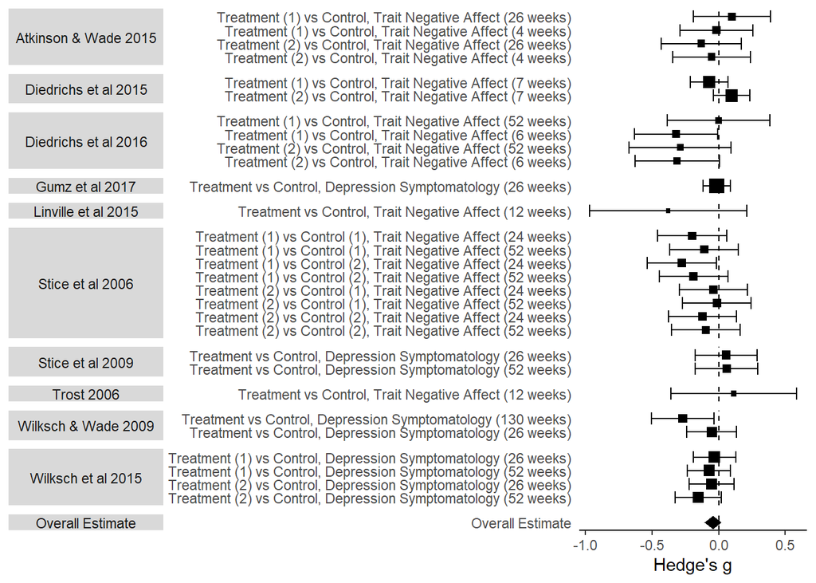

### Risk of bias assessment

```
## RVE: Correlated Effects Model with Small-Sample Corrections
##
## Model: gStd.fu_t2 ~ 1 + precision.fu_t2
##
## Number of studies = 10
## Number of outcomes = 29 (min = 1 , mean = 2.9 , median = 2 , max = 8 )
## Rho = 0.8
## I.sq = 98.8628
## Tau.sq = 1.154054
##
##                   Estimate StdErr t-value  dfs P(|t|>) 95% CI.L 95% CI.U Sig
## 1    X.Intercept.  -0.8202 0.5402  -1.518 4.74   0.193   -2.232    0.592
## 2 precision.fu_t2   0.0342 0.0411   0.831 2.79   0.471   -0.102    0.171
## ---
## Signif. codes: < .01 *** < .05 ** < .10 *
## ---
## Note: If df < 4, do not trust the results
```

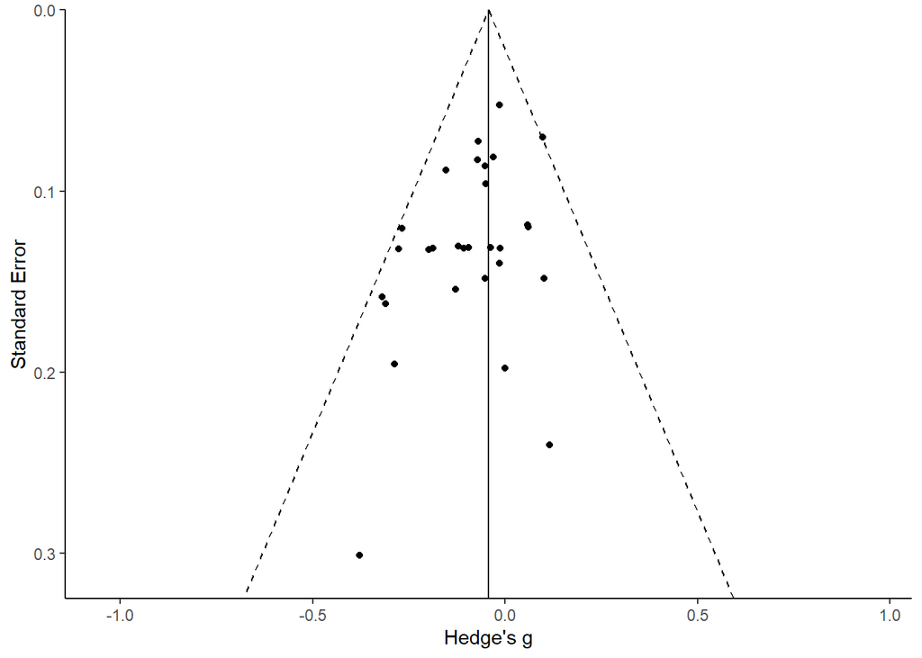

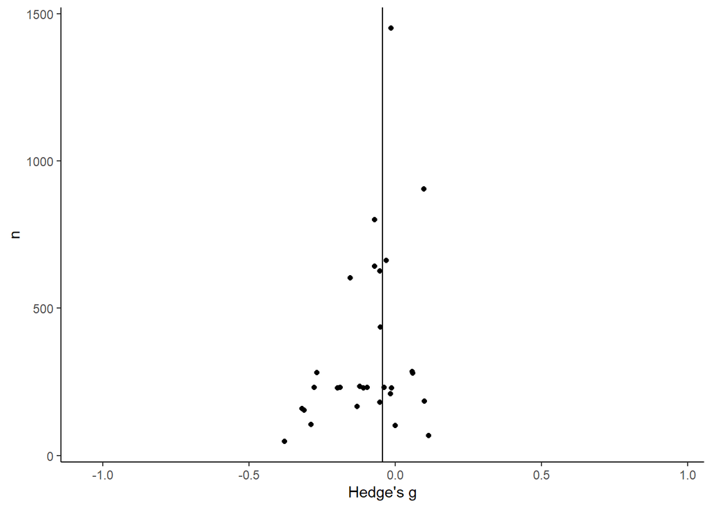

### Moderation tests

| moderator | level | nStudies | nES | Subgroup Analysis subgroupEst | Subgroup Analysis subgroupP | Subgroup Analysis coef | Moderator Test overallStat | Moderator Test overallP |
| --- | --- | --- | --- | --- | --- | --- | --- | --- |
| Year |  | 10 | 29 |  |  | 0.003 | t(3.886) = 0.423 | 0.695 |
| Country |  |  |  |  |  |  | t(2.951) = 0.137 | 0.900 |
|  | Other (Non-North America) | 6 | 17 | -0.050 | 0.168 |  |  |  |
|  | USA | 4 | 12 | -0.037 | 0.688 |  |  |  |
| Intervention Type |  |  |  |  |  |  | t(4.717) = 0.373 | 0.726 |
|  | Indicated prevention | 5 | 16 | -0.073 | 0.398 |  |  |  |
|  | Universal prevention | 4 | 9 | -0.042 | 0.268 |  |  |  |
| Risk Screening |  |  |  |  |  |  | t(4.45) = -0.402 | 0.706 |
|  | No risk screening | 5 | 13 | -0.038 | 0.235 |  |  |  |
|  | Screen on BD | 5 | 16 | -0.073 | 0.398 |  |  |  |
| Mean Age |  | 10 | 29 |  |  | -0.006 | t(3.37) = -0.283 | 0.793 |
| Percent Female |  | 10 | 29 |  |  | -0.001 | t(5.977) = -0.375 | 0.721 |
| Percent Non-white |  | 9 | 28 |  |  | 0.001 | t(1.956) = 0.116 | 0.918 |
| Length (Minutes) |  | 9 | 25 |  |  | 0.000 | t(2.908) = -0.515 | 0.643 |
| Length (Sessions) |  | 10 | 29 |  |  | -0.013 | t(2.179) = -1.817 | 0.200 |
| Length (Days) |  | 10 | 29 |  |  | -0.002 | t(3.055) = -0.845 | 0.459 |
| Treatment Completion Rate |  | 5 | 19 |  |  | -0.005 | t(2.552) = -1.783 | 0.188 |
| Outcome |  |  |  |  |  |  | t(5.184) = -0.159 | 0.879 |
|  | Depression Symptomatology | 4 | 9 | -0.042 | 0.307 |  |  |  |
|  | Trait Negative Affect | 6 | 20 | -0.060 | 0.324 |  |  |  |
| Follow-up Length |  |  |  |  |  |  | t(3.115) = -0.363 | 0.740 |
|  | Between 3 and 12 weeks | 5 | 8 | -0.079 | 0.387 |  |  |  |
|  | Greater than 12 weeks | 7 | 21 | -0.047 | 0.191 |  |  |  |
| Facilitator Supervision |  |  |  |  |  |  | t(3.519) = 1.773 | 0.161 |
|  | No supervision | 4 | 11 | -0.081 | 0.125 |  |  |  |
|  | Supervision | 5 | 14 | -0.016 | 0.498 |  |  |  |
| Follow-up Data Availability |  | 10 | 29 |  |  | 0.001 | t(3.809) = 0.288 | 0.788 |
| Randomized Units |  |  |  |  |  |  | t(2.244) = 0.469 | 0.680 |
|  | < 30 per group | 6 | 17 | -0.050 | 0.168 |  |  |  |
|  | >= 30 per group | 3 | 11 | -0.009 | 0.919 |  |  |  |

*End of follow-up effects analysis.*